# Tuberculosis Case Burden Report

## Introduction

This report examines global tuberculosis (TB) burden using two indicators:

1. **New TB Cases** — reported new cases of all forms of TB
2. **New TB Cases HIV+** — estimated new cases of TB among HIV-positive individuals

The datasets span 1980–2007 for all-form TB and 1990–2007 for HIV-positive TB. Because **2020 is not available** in either dataset, this analysis uses **2007**, the most recent year present in both files.

## New TB Cases (2007)

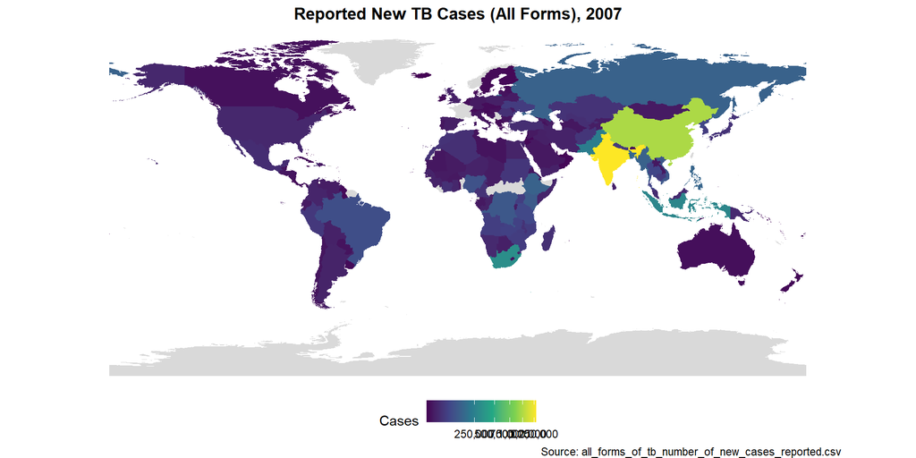

Countries reporting data in 2007: **178**.  
Global total (sum of country values): **5,562,789** cases.

## New TB Cases HIV+ (2007)

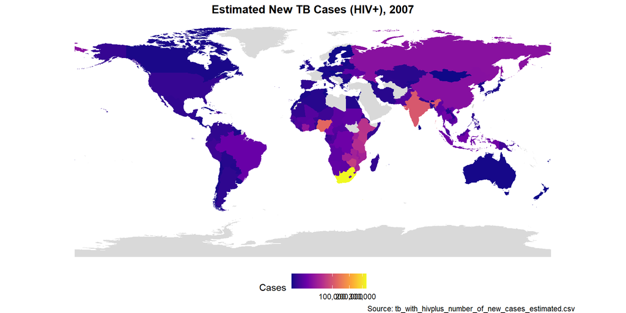

Countries with HIV+ TB estimates in 2007: **143**.  
Global total (sum of country values): **1,374,045** cases.

## Relationship Between Indicators (2007)

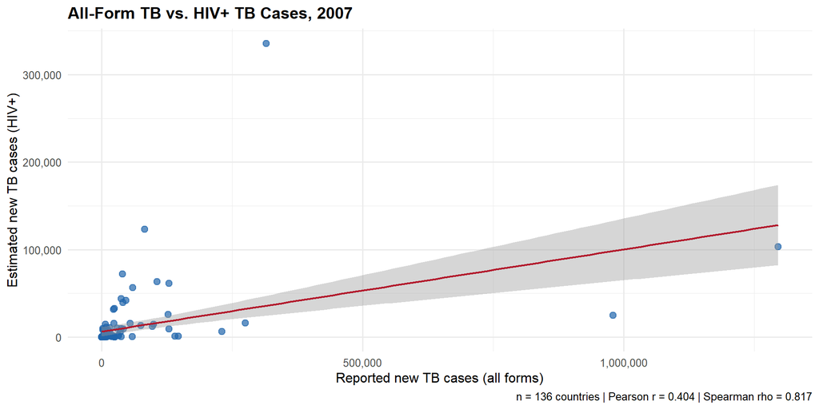

## Interpretation

In 2007, countries with higher reported burdens of all-form tuberculosis also tend to report higher estimated burdens of HIV-associated tuberculosis. Across **136** countries with data for both indicators, the Spearman rank correlation is **0.817**, indicating a **strong positive monotonic association** in country rankings. The Pearson correlation on raw case counts is **0.404**, which is more moderate—partly because a few very large countries (e.g., India, China, South Africa) pull the linear fit without matching the proportional relationship seen across most countries.

The maps show overlapping geographic patterns: the heaviest burdens for both indicators are concentrated in sub-Saharan Africa and parts of Asia (notably India, China, and Indonesia). South Africa stands out with very high HIV+ TB estimates relative to its population, reflecting the intersection of high HIV prevalence and TB transmission.

Together, these findings support treating HIV+ TB as a major component of overall TB morbidity in high-burden settings, while recognizing that strong overall TB counts do not always imply equally high HIV+ TB counts in every country.